# Introduction

While discussing cars, the most common factors considered would be their style, performance, or brand name; however, the underlying combination of features makes up the actual cost of a vehicle. For this project, we used the Car Features and MSRP data set found on Kaggle. The data set consists of information regarding thousands of cars sold in the United States, and each row describes one car in terms of features such as its horsepower, gas mileage, type of drivetrain, number of doors, and market segment. Such a data set is perfect for studying how various attributes affect the MSRP of a car since it can contain both numeric and nominal values. Our goal is to identify which features have the strongest relationship with MSRP and how different types of vehicles cluster within the market. To guide our analysis, we developed one main domain question along with several sub‑questions focused on specific vehicle features.

```r
library(dplyr)      # Data manipulation
library(ggplot2)    # Data visualization
library(scales)     # Formatting
```

# Research Questions

Domain Question:

- What factors most strongly influence a car’s price(MSRP)? This question helps frame the overall purpose of the project identifying which vehicle characteristics are most closely associated with higher or lower prices. Sub Questions: What is the average price for two‑door cars as opposed to four‑door cars? This examines whether basic design features influence MSRP.
- How do engine size, horsepower, or MPG relate to MSRP? This explores performance‑based predictors of price.
- How does drivetrain type (FWD, RWD, AWD) influence average MSRP? This looks at how mechanical systems relate to cost.
- Which car offers the best overall value when considering MSRP, fuel efficiency, and performance?

Together, these questions allow for a complete analysis of how design, performance, and market identity contribute to vehicle pricing.

```r
data <- read.csv("data.csv")
head(data)
```

```
##   Make      Model Year            Engine.Fuel.Type Engine.HP Engine.Cylinders
## 1  BMW 1 Series M 2011 premium unleaded (required)       335                6
## 2  BMW   1 Series 2011 premium unleaded (required)       300                6
## 3  BMW   1 Series 2011 premium unleaded (required)       300                6
## 4  BMW   1 Series 2011 premium unleaded (required)       230                6
## 5  BMW   1 Series 2011 premium unleaded (required)       230                6
## 6  BMW   1 Series 2012 premium unleaded (required)       230                6
##   Transmission.Type    Driven_Wheels Number.of.Doors
## 1            MANUAL rear wheel drive               2
## 2            MANUAL rear wheel drive               2
## 3            MANUAL rear wheel drive               2
## 4            MANUAL rear wheel drive               2
## 5            MANUAL rear wheel drive               2
## 6            MANUAL rear wheel drive               2
##                         Market.Category Vehicle.Size Vehicle.Style highway.MPG
## 1 Factory Tuner,Luxury,High-Performance      Compact         Coupe          26
## 2                    Luxury,Performance      Compact   Convertible          28
## 3               Luxury,High-Performance      Compact         Coupe          28
## 4                    Luxury,Performance      Compact         Coupe          28
## 5                                Luxury      Compact   Convertible          28
## 6                    Luxury,Performance      Compact         Coupe          28
##   city.mpg Popularity  MSRP
## 1       19       3916 46135
## 2       19       3916 40650
## 3       20       3916 36350
## 4       18       3916 29450
## 5       18       3916 34500
## 6       18       3916 31200
```

# Data Cleaning

```r
# Standardize drive wheel labels to abbreviations
data <- data %>%
  mutate(Driven_Wheels = gsub("all wheel drive", "AWD", Driven_Wheels),
         Driven_Wheels = gsub("rear wheel drive", "RWD", Driven_Wheels),
         Driven_Wheels = gsub("front wheel drive", "FWD", Driven_Wheels),
         Driven_Wheels = gsub("four wheel drive", "4WD", Driven_Wheels))
```

The drivetrain column originally had the full names written out like “all wheel drive” and “rear wheel drive,” which made our graphs look really cluttered, especially on the x-axis where the labels would overlap. We swapped them out for the standard abbreviations (AWD, RWD, FWD, 4WD) since those are what most people recognize anyway when they’re shopping for a car. It’s a small change but it made our visualizations way easier to read and gave them a more professional look.

```r
# Consolidate verbose fuel type labels into clean, consistent categories
data <- data %>%
  mutate(Engine.Fuel.Type = case_when(
    Engine.Fuel.Type == "premium unleaded (required)"                  ~ "premium unleaded",
    Engine.Fuel.Type == "premium unleaded (recommended)"               ~ "premium unleaded",
    Engine.Fuel.Type == "flex-fuel (unleaded/E85)"                     ~ "Flex-Fuel",
    Engine.Fuel.Type == "flex-fuel (premium unleaded recommended/E85)" ~ "Flex-Fuel",
    Engine.Fuel.Type == "flex-fuel (premium unleaded required/E85)"    ~ "Flex-Fuel",
    Engine.Fuel.Type == "flex-fuel (unleaded/natural gas)"             ~ "Flex-Fuel",
    Engine.Fuel.Type == "flex-fuel (premium unleaded/E85)"             ~ "Flex-Fuel",
    TRUE ~ Engine.Fuel.Type
  ))
```

When we first ran a summary on the Engine.Fuel.Type column, we realized there were like five different versions of “flex-fuel” being treated as totally separate categories just because the wording in parentheses was slightly different. The same thing was happening with premium unleaded, where “(required)” and “(recommended)” were splitting it into two groups. For our analysis, those distinctions don’t really matter since we just care about the general fuel type, so we merged them all into cleaner categories. This made our groupings actually meaningful instead of having a bunch of tiny categories with only a few cars each.

```r
# Filter out unwanted transmission types and fuel types
data <- data %>%
  filter(!Transmission.Type %in% c("UNKNOWN", "DIRECT_DRIVE")) %>%
  filter(!Engine.Fuel.Type %in% c("", "natural gas", "electric"))
```

We took out a few categories that didn’t fit with the rest of our data. For transmissions, “UNKNOWN” obviously wasn’t useful since we couldn’t say anything about cars where we don’t even know the transmission, and “DIRECT_DRIVE” only showed up in a handful of rows. For fuel types, we dropped natural gas and electric vehicles because on kaggle where we got this dataset from we couldn’t find a conversion for the mpg. After seeing this we decided to just focus on gas vehicles.

```r
# Remove rows with missing values in key numeric columns, as well as cars that cost over a million, as they skew the dataset.
data <- data %>%
  filter(!is.na(Number.of.Doors),
         !is.na(Engine.Cylinders),
          !is.na(Engine.HP)) %>%
  filter(MSRP <= 1000000)
```

For the missing values, we decided to just drop the rows where horsepower, cylinder count, or number of doors were NA. These features are super important to a few of our research questions. Luckily it wasn’t a huge chunk of the dataset, so taking those rows out didn’t really affect the overall results. We also wanted to focus on cars that were under 1 million dollars since most cars after that price range are realistic for what we are researching.

```r
# this is to take out one outlire that is not accurate

data <- data %>%
  filter(highway.MPG <= 200)
```

While we were exploring the data we noticed one row with a highway MPG over 200, which is obviously not real since no gas car gets that kind of mileage. It was clearly a data entry error, so we filtered out anything above 200 MPG to clean it up. Without doing this, our MPG vs MSRP scatterplot had this one weird point way off to the right that squished all the actual data into a tiny corner of the graph.

# Data

```r
glimpse(data)
```

```
## Rows: 11,769
## Columns: 16
## $ Make              <chr> "BMW", "BMW", "BMW", "BMW", "BMW", "BMW", "BMW", "BM…
## $ Model             <chr> "1 Series M", "1 Series", "1 Series", "1 Series", "1…
## $ Year              <int> 2011, 2011, 2011, 2011, 2011, 2012, 2012, 2012, 2012…
## $ Engine.Fuel.Type  <chr> "premium unleaded", "premium unleaded", "premium unl…
## $ Engine.HP         <int> 335, 300, 300, 230, 230, 230, 300, 300, 230, 230, 30…
## $ Engine.Cylinders  <int> 6, 6, 6, 6, 6, 6, 6, 6, 6, 6, 6, 6, 6, 6, 6, 6, 6, 6…
## $ Transmission.Type <chr> "MANUAL", "MANUAL", "MANUAL", "MANUAL", "MANUAL", "M…
## $ Driven_Wheels     <chr> "RWD", "RWD", "RWD", "RWD", "RWD", "RWD", "RWD", "RW…
## $ Number.of.Doors   <int> 2, 2, 2, 2, 2, 2, 2, 2, 2, 2, 2, 2, 2, 2, 2, 2, 2, 4…
## $ Market.Category   <chr> "Factory Tuner,Luxury,High-Performance", "Luxury,Per…
## $ Vehicle.Size      <chr> "Compact", "Compact", "Compact", "Compact", "Compact…
## $ Vehicle.Style     <chr> "Coupe", "Convertible", "Coupe", "Coupe", "Convertib…
## $ highway.MPG       <int> 26, 28, 28, 28, 28, 28, 26, 28, 28, 27, 28, 28, 28, …
## $ city.mpg          <int> 19, 19, 20, 18, 18, 18, 17, 20, 18, 18, 20, 19, 19, …
## $ Popularity        <int> 3916, 3916, 3916, 3916, 3916, 3916, 3916, 3916, 3916…
## $ MSRP              <int> 46135, 40650, 36350, 29450, 34500, 31200, 44100, 393…
```

The Car Features and MSRP dataset consists of extensive data on numerous automobiles that were bought in the American market. In the dataset, one record refers to one car. Every attribute in a given record refers to some car feature. Some of the attributes found in this dataset include numeric variables like engine power, cylinders, city fuel efficiency, and highway fuel efficiency. Moreover, we also have some categorical attributes like drivetrain type, door type, transmission type, fuel type, and category. All these factors help us in having a clear understanding of how the different car models differ from one another in terms of their physical structure and mechanics. This dataset consists of both performance and economy cars, which makes it very suitable for studying price differences among them.

# Sub Question 1

What is the average price for two door cars as opposed to four door cars?

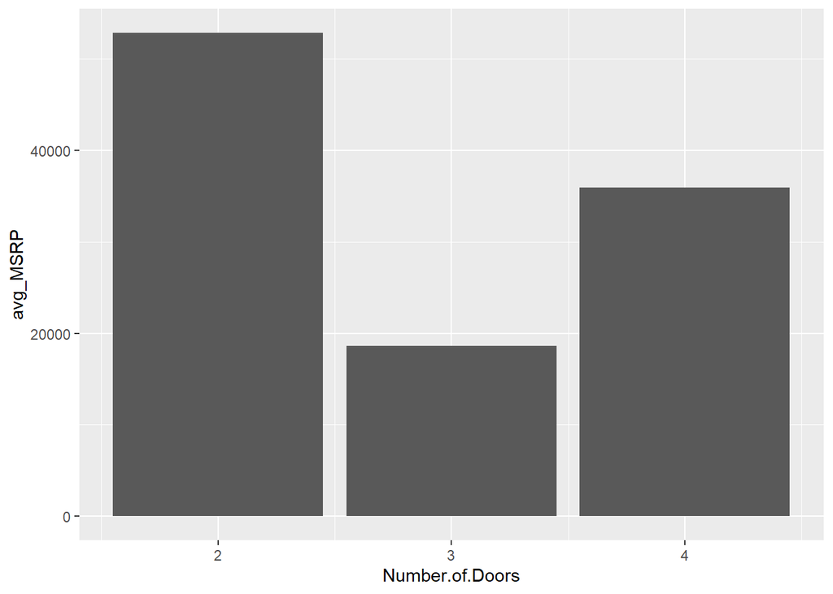

```r
data %>%
  group_by(Number.of.Doors) %>%
  summarize(avg_MSRP = mean(MSRP, na.rm = TRUE)) %>%
  ggplot(aes(x = Number.of.Doors, y = avg_MSRP)) +
  geom_col()
```

```r
#this checks the average of each type of Number.of.Doors
```

- Two‑door cars tend to have higher average MSRPs, often due to sports/performance models car. In this bar graph, you can see the comparison of average MSRP in relation to the number of doors. The average MSRP of two-door cars is much higher compared to four door cars because most two-door cars belong to the performance class of cars.

# Sub question 2

How does drivetrain type (FWD, RWD, AWD) influence average MSRP?

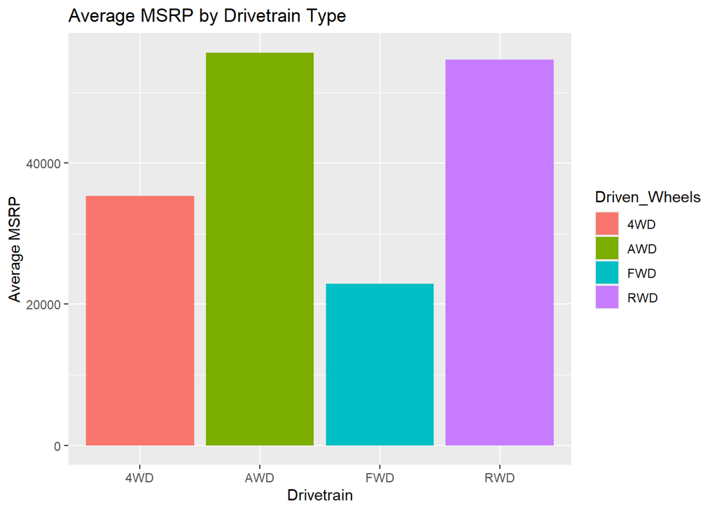

```r
data %>%
  group_by(Driven_Wheels) %>%
  summarize(avg_MSRP = mean(MSRP, na.rm = TRUE)) %>%
  ggplot(aes(x = Driven_Wheels, y = avg_MSRP, fill = Driven_Wheels)) +
  geom_col() +
  labs(title = "Average MSRP by Drivetrain Type",
       x = "Drivetrain",
       y = "Average MSRP")
```

The bar graph below demonstrates the variation in the average MSRP of cars according to their drivetrain type. In this case, cars that have the AWD drivetrain type are the most expensive, followed by RWD and FWD respectively.

# Sub question 3

How do engine size, horsepower, or MPG relate to MSRP?

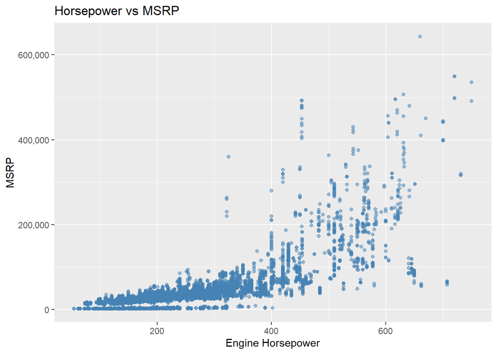

```r
# Horsepower vs MSRP
ggplot(data, aes(x = Engine.HP, y = MSRP)) +
  geom_point(alpha = 0.5, color = "steelblue") +
  scale_y_continuous(labels = scales::label_comma()) +
  labs(title = "Horsepower vs MSRP",
       x = "Engine Horsepower",
       y = "MSRP")
```

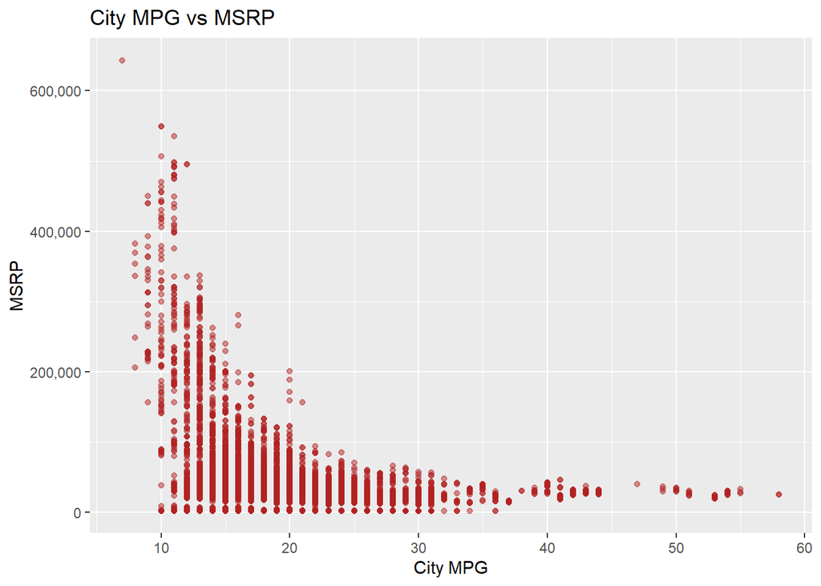

```r
# City MPG vs MSRP
ggplot(data, aes(x = city.mpg, y = MSRP)) +
  geom_point(alpha = 0.5, color = "firebrick") +
  scale_y_continuous(labels = scales::label_comma()) +
  labs(title = "City MPG vs MSRP",
       x = "City MPG",
       y = "MSRP")
```

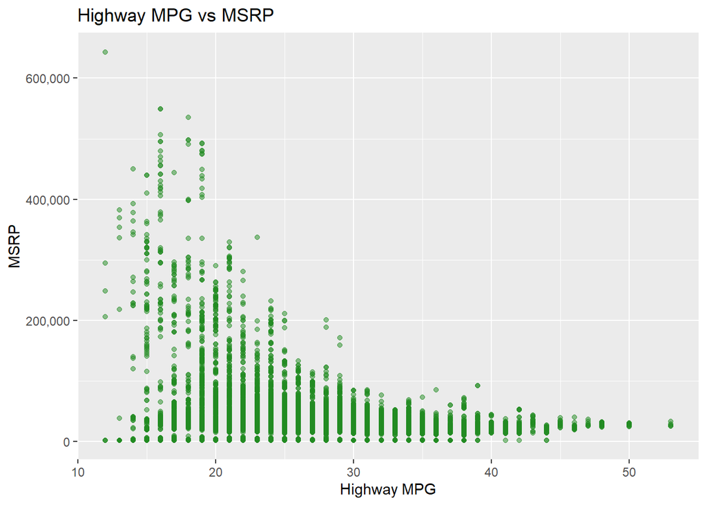

```r
# Highway MPG vs MSRP
ggplot(data, aes(x = highway.MPG, y = MSRP)) +
  geom_point(alpha = 0.5, color = "forestgreen") +
  scale_y_continuous(labels = scales::label_comma()) +
  labs(title = "Highway MPG vs MSRP",
       x = "Highway MPG",
       y = "MSRP")
```

# sub question 4

Which car offers the best overall value when considering MSRP, fuel efficiency, and performance?

```r
top_unique_cars <- data %>%
  filter(!is.na(MSRP), !is.na(city.mpg), !is.na(highway.MPG)) %>%
  mutate(
    msrp_score = (max(MSRP) - MSRP) / (max(MSRP) - min(MSRP)),
    city_score = (city.mpg - min(city.mpg)) / (max(city.mpg) - min(city.mpg)),
    highway_score = (highway.MPG - min(highway.MPG)) / (max(highway.MPG) - min(highway.MPG)),
    total_score = msrp_score + city_score + highway_score
  ) %>%
  arrange(desc(total_score)) %>%
  group_by(Make) %>%        # group by brand
  slice(1) %>%              # take BEST car per brand
  ungroup() %>%
  arrange(desc(total_score)) %>%  # rank again across brands
  select(Make, Model, Year, MSRP, city.mpg, highway.MPG, total_score) %>%
  slice(1:10)

top_unique_cars
```

```
## # A tibble: 10 × 7
##    Make       Model          Year  MSRP city.mpg highway.MPG total_score
##    <chr>      <chr>         <int> <int>    <int>       <int>       <dbl>
##  1 Toyota     Prius          2016 24700       58          53        2.96
##  2 Honda      Accord Hybrid  2017 29605       49          47        2.63
##  3 Volkswagen Jetta Hybrid   2013 24995       42          48        2.53
##  4 Kia        Optima Hybrid  2017 25995       39          46        2.42
##  5 Ford       Fusion Hybrid  2016 25675       44          41        2.40
##  6 Hyundai    Sonata Hybrid  2017 26000       39          45        2.39
##  7 Mitsubishi Mirage         2014 13995       37          44        2.35
##  8 Lexus      CT 200h        2016 31250       43          40        2.34
##  9 Lincoln    MKZ            2015 35190       41          39        2.27
## 10 Chevrolet  Metro          1999  2000       34          42        2.26
```

# Result

### Main Question: What factors most strongly influence MSRP?

MSRP is mainly influenced by horsepower (positive relationship), drivetrain type (AWD highest), and fuel efficiency (negative relationship with MPG).

### Sub Question 1: Two-door vs four-door pricing?

Two-door cars have a higher average MSRP than four-door cars, likely due to performance-focused designs.

### Sub Question 2: Drivetrain impact on MSRP?

AWD vehicles have the highest average MSRP, followed by RWD, then FWD.

### Sub Question 3: Engine size, horsepower, MPG vs MSRP?

Higher horsepower increases MSRP, while higher MPG (city and highway) decreases MSRP.

### Sub Question 4: Best value cars?

Hybrid vehicles (like the Toyota Prius) rank highest because they balance low cost with high fuel efficiency. top_unique_cars